# Business Case: Target SQL

Scaler DS ML

Shayantan Dey

30th July

### Context:

Target is a globally renowned brand and a prominent retailer in the United States. Target makes itself a preferred shopping destination by offering outstanding value, inspiration, innovation and an exceptional guest experience that no other retailer can deliver.

This particular business case focuses on the operations of Target in Brazil and provides insightful information about 100,000 orders placed between 2016 and 2018. The dataset offers a comprehensive view of various dimensions including the order status, price, payment and freight performance, customer location, product attributes, and customer reviews.

By analyzing this extensive dataset, it becomes possible to gain valuable insights into Target’s operations in Brazil. The information can shed light on various aspects of the business, such as order processing, pricing strategies, payment and shipping efficiency, customer demographics, product characteristics, and customer satisfaction levels.

### Dataset:

The data is available in 8 csv files at [Google Drive](https://drive.google.com/drive/folders/1TGEc66YKbD443nslRi1bWgVd238gJCnb)

1. customers.csv
2. sellers.csv
3. order_items.csv
4. geolocation.csv
5. payments.csv
6. reviews.csv
7. orders.csv
8. products.csv

### Dataset schema:

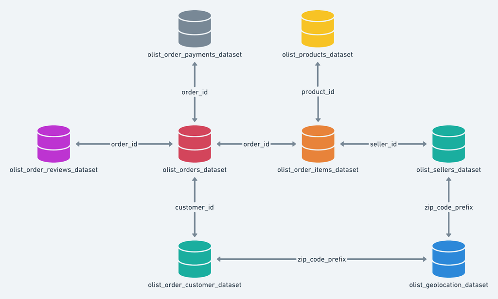

### Observations in the dataset

Two files, order_reviews.csv and geolocation.csv had unclean data.

**Issues Identified in the order_reviews.csv file:**

*Encoding Issue:* The file had to be read with ISO-8859-1 encoding instead of UTF-8.

*Null Values:* The review_comment_title column has many null values.

*Date and Time Formatting:* The review_creation_date and review_answer_timestamp columns are in string format and not properly parsed as datetime objects.

*Steps to Correct Issues:*

1. Ensure consistent encoding.
2. Handle null values in review_comment_title.
3. Convert date and time columns to proper datetime format.

*Cleaning Data:*

1. Strip leading/trailing spaces in text fields.
2. Replace any special characters or non-UTF-8 characters in text fields.
3. Check for null or empty values and handle them appropriately.
4. Convert date and time columns to datetime format.

**Issues Identified in the geolocation.csv file:**

*Encoding Issue:* The file had to be read with ISO-8859-1 encoding instead of UTF-8.

*Null Values:* The review_comment_title column has many null values.

*Date and Time Formatting:* The review_creation_date and review_answer_timestamp columns are in string format and not properly parsed as datetime objects.

*Steps to Correct Issues:*

1. Special characters in text fields.
2. Trailing or leading spaces.
3. Null or empty values.
4. Ensure that the file does not have any rows that might cause issues.

*Cleaning Data:*

1. Strip leading/trailing spaces in text fields.
2. Replace any special characters or non-UTF-8 characters in text fields.
3. Check for null or empty values and handle them appropriately.

All the 27 *geolocation_state* listed in the *geolocations.csv* file and *customer_state* in *customers.csv* are 26 states and 1 federal territory of Brazil. Hence, the data is specific to Brazil customers.

### Problem Statement:

Assuming you are a data analyst/ scientist at Target, you have been assigned the task of analyzing the given dataset to extract valuable insights and provide actionable recommendations.

**What does ‘good’ look like?**

**1. Import the dataset and do usual exploratory analysis steps like checking the structure & characteristics of the dataset:**

1.1. Data type of all columns in the “customers” table.

```sql
DESCRIBE customers;
```

| Field | Type | Null | Key | Default | Extra |
| --- | --- | --- | --- | --- | --- |
| customer_id | text | YES |  | NA |  |
| customer_unique_id | text | YES |  | NA |  |
| customer_zip_code_prefix | text | YES |  | NA |  |
| customer_city | text | YES |  | NA |  |
| customer_state | text | YES |  | NA |  |

1.2. Get the time range between which the orders were placed.

```sql
SELECT
    MIN(order_purchase_timestamp) AS order_start_date,
    MAX(order_purchase_timestamp) AS order_end_date,
    DATEDIFF(MAX(order_purchase_timestamp), MIN(order_purchase_timestamp))
      AS order_time_range_days
FROM
    orders;
```

[output not shown]

1.3. Count the Cities & States of customers who ordered during the given period.

```sql
SELECT DISTINCT c.customer_city, c.customer_state, COUNT(*) AS customer_count
FROM orders AS o
JOIN customers AS c
ON o.customer_id = c.customer_id
GROUP BY c.customer_city, c.customer_state
ORDER BY customer_count DESC
```

| customer_city | customer_state | customer_count |
| --- | --- | --- |
| sao paulo | SP | 15540 |
| rio de janeiro | RJ | 6882 |
| belo horizonte | MG | 2773 |
| brasilia | DF | 2131 |
| curitiba | PR | 1521 |
| campinas | SP | 1444 |
| porto alegre | RS | 1379 |
| salvador | BA | 1245 |
| guarulhos | SP | 1189 |
| sao bernardo do campo | SP | 938 |

[output cut: 990 more lines]

**2. In-depth Exploration:**

2.1 Is there a growing trend in the no. of orders placed over the past years?

The purchases were made in the year 2016, 2017 and 2018.

```sql
SELECT DISTINCT YEAR(order_purchase_timestamp) AS year_of_orders
FROM orders
ORDER BY year_of_orders;
```

Trend for 2016 does not show conclusive evidence of a growing trend.

```sql
SELECT DISTINCT CONCAT(MONTHNAME(order_purchase_timestamp), " ", "2016") AS month,
       COUNT(order_id) OVER (PARTITION BY MONTH(order_purchase_timestamp))
          AS order_count,
       MONTH(order_purchase_timestamp) AS month_number
FROM orders
WHERE YEAR(order_purchase_timestamp) = 2016
ORDER BY MONTH(order_purchase_timestamp);
```

```sql
SELECT DISTINCT CONCAT(MONTHNAME(order_purchase_timestamp), " ", "2017") AS month,
       COUNT(order_id) OVER (PARTITION BY MONTH(order_purchase_timestamp))
        AS order_count,
       MONTH(order_purchase_timestamp) AS month_number
FROM orders
WHERE YEAR(order_purchase_timestamp) = 2017
ORDER BY MONTH(order_purchase_timestamp);
```

```sql
SELECT DISTINCT CONCAT(MONTHNAME(order_purchase_timestamp), " ", "2018") AS month,
       COUNT(order_id) OVER (PARTITION BY MONTH(order_purchase_timestamp))
        AS order_count,
       MONTH(order_purchase_timestamp) AS month_number
FROM orders
WHERE YEAR(order_purchase_timestamp) = 2018
ORDER BY MONTH(order_purchase_timestamp);
```

Finding the sales per year shows a year-on-year growing trend.

```sql
SELECT DISTINCT YEAR(order_purchase_timestamp) AS year,
       COUNT(order_id) OVER(PARTITION BY YEAR(order_purchase_timestamp)) AS count_of_orders
FROM orders;
```

| year | count_of_orders |
| --- | --- |
| 2016 | 329 |
| 2017 | 45101 |
| 2018 | 54011 |

2.2. Can we see some kind of monthly seasonality in terms of the no. of orders being placed?

Highest monthly sales in the given data is as follows, but it fails to show any seasonal trend:

```sql
SELECT YEAR(order_purchase_timestamp) as year,
       MONTHNAME(order_purchase_timestamp) as month,
       COUNT(*) as order_count
FROM orders
GROUP BY year, month
ORDER BY order_count DESC;
```

| year | month | order_count |
| --- | --- | --- |
| 2017 | November | 7544 |
| 2018 | January | 7269 |
| 2018 | March | 7211 |
| 2018 | April | 6939 |
| 2018 | May | 6873 |
| 2018 | February | 6728 |
| 2018 | August | 6512 |
| 2018 | July | 6292 |
| 2018 | June | 6167 |
| 2017 | December | 5673 |

[output cut: 15 more lines]

While checking the year-wise monthly sales data, we do not see any monthly seasonality:

```sql
SELECT DISTINCT CONCAT(MONTHNAME(order_purchase_timestamp), " ", "2016") as month,
       MONTH(order_purchase_timestamp) as month_number,
       COUNT(order_id) OVER (PARTITION BY MONTH(order_purchase_timestamp))
        AS order_count
FROM orders
WHERE YEAR(order_purchase_timestamp) = 2016 AND LOWER(order_status) <> 'canceled'
ORDER BY order_count DESC;
```

| month | month_number | order_count |
| --- | --- | --- |
| October 2016 | 10 | 300 |
| September 2016 | 9 | 2 |
| December 2016 | 12 | 1 |

```sql
SELECT DISTINCT CONCAT(MONTHNAME(order_purchase_timestamp), " ", "2017") AS month,
       MONTH(order_purchase_timestamp) AS month_number,
       COUNT(order_id) OVER (PARTITION BY MONTH(order_purchase_timestamp))
        AS order_count
FROM orders
WHERE YEAR(order_purchase_timestamp) = 2017
ORDER BY order_count DESC;
```

```sql
SELECT DISTINCT CONCAT(MONTHNAME(order_purchase_timestamp), " ", "2018") as month,
       MONTH(order_purchase_timestamp) as month_number,
       COUNT(order_id) OVER (PARTITION BY MONTH(order_purchase_timestamp))
        AS order_count
FROM orders
WHERE YEAR(order_purchase_timestamp) = 2018
ORDER BY order_count DESC;
```

| month | month_number | order_count |
| --- | --- | --- |
| January 2018 | 1 | 7269 |
| March 2018 | 3 | 7211 |
| April 2018 | 4 | 6939 |
| May 2018 | 5 | 6873 |
| February 2018 | 2 | 6728 |
| August 2018 | 8 | 6512 |
| July 2018 | 7 | 6292 |
| June 2018 | 6 | 6167 |
| September 2018 | 9 | 16 |
| October 2018 | 10 | 4 |

2.3. During what time of the day, do the Brazilian customers mostly place their orders? (Dawn, Morning, Afternoon or Night)

0-6 hrs : Dawn  
7-12 hrs : Mornings  
13-18 hrs : Afternoon  
19-23 hrs : Night

As per the data, Brazilian customers prefer placing their orders during afternoon.

```sql
WITH d AS (SELECT customer_id, order_purchase_timestamp,
       CASE
          WHEN FLOOR(EXTRACT(HOUR FROM order_purchase_timestamp)) BETWEEN 0 AND 6 THEN
            "Dawn"
          WHEN FLOOR(EXTRACT(HOUR FROM order_purchase_timestamp)) BETWEEN 7 AND 12 THEN
            "Mornings"
          WHEN FLOOR(EXTRACT(HOUR FROM order_purchase_timestamp)) BETWEEN 13 AND 18 THEN
            "Afternoon"
          WHEN FLOOR(EXTRACT(HOUR FROM order_purchase_timestamp)) BETWEEN 19 AND 23 THEN
            "Night"
       END AS time_of_day
FROM orders)
SELECT DISTINCT d.time_of_day, COUNT(d.time_of_day) OVER(PARTITION BY d.time_of_day)
        AS count_of_orders
FROM d
ORDER BY count_of_orders DESC;
```

| time_of_day | count_of_orders |
| --- | --- |
| Afternoon | 38135 |
| Night | 28331 |
| Mornings | 27733 |
| Dawn | 5242 |

**3. Evolution of E-commerce orders in the Brazil region:**

3.1. Get the month on month no. of orders placed in each state.

```sql
SELECT c.customer_state,
    EXTRACT(YEAR FROM o.order_purchase_timestamp) AS year,
    MONTHNAME(o.order_purchase_timestamp) AS month_name,
    EXTRACT(MONTH FROM o.order_purchase_timestamp) AS month_number,
    COUNT(o.order_id) AS order_count
FROM customers as c
JOIN orders as o
ON c.customer_id = o.customer_id
GROUP By c.customer_state,
    EXTRACT(YEAR FROM o.order_purchase_timestamp),
    MONTHNAME(o.order_purchase_timestamp),
    EXTRACT(MONTH FROM o.order_purchase_timestamp)
ORDER BY c.customer_state, year, month_number;
```

| customer_state | year | month_name | month_number | order_count |
| --- | --- | --- | --- | --- |
| AC | 2017 | January | 1 | 2 |
| AC | 2017 | February | 2 | 3 |
| AC | 2017 | March | 3 | 2 |
| AC | 2017 | April | 4 | 5 |
| AC | 2017 | May | 5 | 8 |
| AC | 2017 | June | 6 | 4 |
| AC | 2017 | July | 7 | 5 |
| AC | 2017 | August | 8 | 4 |
| AC | 2017 | September | 9 | 5 |
| AC | 2017 | October | 10 | 6 |

[output cut: 555 more lines]

3.2. How are the customers distributed across all the states?

Distribution of customers across states is as follows:

```sql
SELECT customer_state,
       COUNT(*) AS count_of_customers
FROM customers
GROUP BY customer_state
ORDER BY customer_state;
```

| customer_state | count_of_customers |
| --- | --- |
| AC | 81 |
| AL | 413 |
| AM | 148 |
| AP | 68 |
| BA | 3380 |
| CE | 1336 |
| DF | 2140 |
| ES | 2033 |
| GO | 2020 |
| MA | 747 |

[output cut: 17 more lines]

Distribution of customers across cities in those states is as follows:

```sql
SELECT customer_state, customer_city,
       COUNT(*) AS count_of_customers
FROM customers
GROUP BY customer_state, customer_city
ORDER BY customer_state, customer_city;
```

| customer_state | customer_city | count_of_customers |
| --- | --- | --- |
| AC | brasileia | 1 |
| AC | cruzeiro do sul | 3 |
| AC | epitaciolandia | 1 |
| AC | manoel urbano | 1 |
| AC | porto acre | 1 |
| AC | rio branco | 70 |
| AC | senador guiomard | 2 |
| AC | xapuri | 2 |
| AL | agua branca | 1 |
| AL | anadia | 2 |

[output cut: 990 more lines]

**4. Impact on Economy: Analyze the money movement by e-commerce by looking at order prices, freight and others.**

4.1. Get the % increase in the cost of orders from year 2017 to 2018 (include months between Jan to Aug only). You can use the “payment_value” column in the payments table to get the cost of orders.

```sql
WITH d AS (SELECT EXTRACT(YEAR FROM o.order_purchase_timestamp) AS year,
       p.payment_value
       FROM orders as o
       JOIN payments as p
       ON o.order_id = p.order_id
       WHERE (o.order_purchase_timestamp BETWEEN '2017-01-01' AND '2017-08-31')
         OR (o.order_purchase_timestamp BETWEEN '2018-01-01' AND '2018-08-31')),

    d2 AS (SELECT DISTINCT d.year,
       SUM(d.payment_value) OVER (PARTITION BY d.year) as yearly_payment_value
       FROM d),

    d3 AS (SELECT d2.year, d2.yearly_payment_value,
           LEAD(d2.yearly_payment_value) OVER(ORDER BY d2.yearly_payment_value)
              AS lead_,
           ((LEAD(d2.yearly_payment_value) OVER(ORDER BY d2.yearly_payment_value)
             - d2.yearly_payment_value)) as diff
           FROM d2)

SELECT d3.yearly_payment_value as 2017_payment_value,
       d3.lead_ as 2018_payment_value,
       ROUND((d3.diff/d3.yearly_payment_value) * 100, 2)
          as 2017_to_2018_percentage_increase
FROM d3
WHERE d3.lead_ IS NOT NULL;
```

| 2017_payment_value | 2018_payment_value | 2017_to_2018_percentage_increase |
| --- | --- | --- |
| 3645107 | 8694670 | 138.53 |

Foe example, excluding the orders with *canceled* status changes the results as follows:

```sql
WITH d AS (SELECT EXTRACT(YEAR FROM o.order_purchase_timestamp) AS year,
       p.payment_value
       FROM orders as o
       JOIN payments as p
       ON o.order_id = p.order_id
       WHERE ((o.order_purchase_timestamp BETWEEN '2017-01-01' AND '2017-08-31')
         OR (o.order_purchase_timestamp BETWEEN '2018-01-01' AND '2018-08-31'))
         AND (o.order_status <> "canceled")),

    d2 AS (SELECT DISTINCT d.year,
       SUM(d.payment_value) OVER (PARTITION BY d.year) as yearly_payment_value
       FROM d),

    d3 AS (SELECT d2.year, d2.yearly_payment_value,
           LEAD(d2.yearly_payment_value) OVER(ORDER BY d2.yearly_payment_value)
              AS lead_,
           ((LEAD(d2.yearly_payment_value) OVER(ORDER BY d2.yearly_payment_value)
             - d2.yearly_payment_value)) as diff
           FROM d2)

SELECT d3.yearly_payment_value as 2017_payment_value,
       d3.lead_ as 2018_payment_value,
       ROUND((d3.diff/d3.yearly_payment_value) * 100, 2)
          as 2017_to_2018_percentage_increase
FROM d3
WHERE d3.lead_ IS NOT NULL;
```

| 2017_payment_value | 2018_payment_value | 2017_to_2018_percentage_increase |
| --- | --- | --- |
| 3604147 | 8624465 | 139.29 |

4.2. Calculate the Total & Average value of order price for each state.

```sql
SELECT DISTINCT c.customer_state,
       ROUND(SUM(p.payment_value) OVER(PARTITION BY c.customer_state), 2)
          AS total_order_price,
       ROUND(AVG(p.payment_value) OVER(PARTITION BY c.customer_state), 2)
          AS average_order_price
FROM customers AS c
JOIN orders AS o
ON c.customer_id = o.customer_id
JOIN payments as p
ON o.order_id = p.order_id
ORDER BY c.customer_state;
```

| customer_state | total_order_price | average_order_price |
| --- | --- | --- |
| AC | 19680.62 | 234.29 |
| AL | 96962.06 | 227.08 |
| AM | 27966.93 | 181.60 |
| AP | 16262.80 | 232.33 |
| BA | 616645.82 | 170.82 |
| CE | 279464.03 | 199.90 |
| DF | 355141.08 | 161.13 |
| ES | 325967.55 | 154.71 |
| GO | 350092.31 | 165.76 |
| MA | 152523.02 | 198.86 |

[output cut: 17 more lines]

4.3. Calculate the Total & Average value of order freight for each state.

```sql
SELECT DISTINCT c.customer_state,
       ROUND(SUM(oi.freight_value) OVER(PARTITION BY c.customer_state), 2)
          AS total_freight_price,
       ROUND(AVG(oi.freight_value) OVER(PARTITION BY c.customer_state), 2)
          AS average_freight_price
FROM customers AS c
JOIN orders AS o
ON c.customer_id = o.customer_id
JOIN order_items AS oi
ON o.order_id = oi.order_id
ORDER BY c.customer_state;
```

| customer_state | total_freight_price | average_freight_price |
| --- | --- | --- |
| AC | 3686.75 | 40.07 |
| AL | 15914.59 | 35.84 |
| AM | 5478.89 | 33.21 |
| AP | 2788.50 | 34.01 |
| BA | 100156.68 | 26.36 |
| CE | 48351.59 | 32.71 |
| DF | 50625.50 | 21.04 |
| ES | 49764.60 | 22.06 |
| GO | 53114.98 | 22.77 |
| MA | 31523.77 | 38.26 |

[output cut: 17 more lines]

**5. Analysis based on sales, freight and delivery time.**

5.1. Find the no. of days taken to deliver each order from the order’s purchase date as delivery time. Also, calculate the difference (in days) between the estimated & actual delivery date of an order. Do this in a single query.

You can calculate the delivery time and the difference between the estimated & actual delivery date using the given formula:  
time_to_deliver = order_delivered_customer_date - order_purchase_timestamp  
diff_estimated_delivery = order_delivered_customer_date - order_estimated_delivery_date

Checking for the missing values, we find that *order_delivered_customer_date* is  
is missing in the dataset for many rows across all *order_status*. This should be  
considered as unclean data and it will adversely affect the analysis.

```sql
SELECT DISTINCT order_status,
       COUNT(CASE WHEN order_delivered_customer_date = "" THEN 1 END)
          OVER (PARTITION BY order_status ORDER BY order_delivered_customer_date)
              AS null_delivered_date,
       COUNT(CASE WHEN order_purchase_timestamp = "" THEN 1 END)
          OVER (PARTITION BY order_status ORDER BY order_purchase_timestamp)
              AS null_purchase_timestamp,
       COUNT(CASE WHEN order_estimated_delivery_date = "" THEN 1 END)
          OVER (PARTITION BY order_status ORDER BY order_estimated_delivery_date)
              AS null_estimated_delivery
FROM orders;
```

[output not shown]

Calculating *time_to_deliver* and *diff_estimated_delivery*, we observe that  
time to deliver and estimated delivery are a major concern that requires improvement.

```sql
SELECT order_id, order_status,
       DATEDIFF(order_delivered_customer_date, order_purchase_timestamp)
          AS time_to_deliver,
       DATEDIFF(order_delivered_customer_date, order_estimated_delivery_date)
          AS diff_estimated_delivery
FROM orders
ORDER BY diff_estimated_delivery DESC;
```

| order_id | order_status | time_to_deliver | diff_estimated_delivery |
| --- | --- | --- | --- |
| 1b3190b2dfa9d789e1f14c05b647a14a | delivered | 208 | 188 |
| ca07593549f1816d26a572e06dc1eab6 | delivered | 210 | 181 |
| 47b40429ed8cce3aee9199792275433f | delivered | 191 | 175 |
| 2fe324febf907e3ea3f2aa9650869fa5 | delivered | 190 | 167 |
| 285ab9426d6982034523a855f55a885e | delivered | 195 | 166 |
| 440d0d17af552815d15a9e41abe49359 | delivered | 196 | 165 |
| c27815f7e3dd0b926b58552628481575 | delivered | 188 | 162 |
| d24e8541128cea179a11a65176e0a96f | delivered | 175 | 161 |
| 0f4519c5f1c541ddec9f21b3bddd533a | delivered | 194 | 161 |
| 2d7561026d542c8dbd8f0daeadf67a43 | delivered | 188 | 159 |

[output cut: 990 more lines]

6535 orders had actual delivery later than the estimated delivery.  
Estimation of delivery date should be revised.

```sql
SELECT COUNT(*) AS delivery_estimate_miss
FROM orders
WHERE DATEDIFF(order_delivered_customer_date, order_estimated_delivery_date) >= 1;
```

[output not shown]

5.2. Find out the top 5 states with the highest & lowest average freight value.

```sql
SELECT DISTINCT c.customer_state,
       AVG(oi.freight_value) OVER (PARTITION BY c.customer_state) as highest_5_avg
FROM order_items AS oi
JOIN orders AS o
ON oi.order_id = o.order_id
JOIN customers AS c
ON o.customer_id = c.customer_id
ORDER BY highest_5_avg DESC
LIMIT 5;
```

| customer_state | highest_5_avg |
| --- | --- |
| RR | 42.98442 |
| PB | 42.72380 |
| RO | 41.06971 |
| AC | 40.07337 |
| PI | 39.14797 |

```sql
SELECT DISTINCT c.customer_state,
       AVG(oi.freight_value) OVER (PARTITION BY c.customer_state) as lowest_5_avg
FROM order_items AS oi
JOIN orders AS o
ON oi.order_id = o.order_id
JOIN customers AS c
ON o.customer_id = c.customer_id
ORDER BY lowest_5_avg
LIMIT 5;
```

| customer_state | lowest_5_avg |
| --- | --- |
| SP | 15.14728 |
| PR | 20.53165 |
| MG | 20.63017 |
| RJ | 20.96092 |
| DF | 21.04135 |

5.3. Find out the top 5 states with the highest & lowest average delivery time.

```sql
SELECT DISTINCT c.customer_state,
       AVG(DATEDIFF(order_delivered_customer_date, order_purchase_timestamp))
          OVER (PARTITION BY c.customer_state) as highest_5_avg
FROM orders AS o
JOIN customers AS c
ON o.customer_id = c.customer_id
ORDER BY highest_5_avg DESC
LIMIT 5;
```

| customer_state | highest_5_avg |
| --- | --- |
| RR | 29.3415 |
| AP | 27.1791 |
| AM | 26.3586 |
| AL | 24.5013 |
| PA | 23.7252 |

```sql
SELECT DISTINCT c.customer_state,
       AVG(DATEDIFF(order_delivered_customer_date, order_purchase_timestamp))
          OVER (PARTITION BY c.customer_state) as lowest_5_avg
FROM orders AS o
JOIN customers AS c
ON o.customer_id = c.customer_id
ORDER BY lowest_5_avg
LIMIT 5;
```

| customer_state | lowest_5_avg |
| --- | --- |
| SP | 8.7005 |
| PR | 11.9380 |
| MG | 11.9465 |
| DF | 12.8990 |
| SC | 14.9075 |

5.4. Find out the top 5 states where the order delivery is really fast as compared to the estimated date of delivery.  
You can use the difference between the averages of actual & estimated delivery date to figure out how fast the delivery was for each state.

```sql
SELECT DISTINCT c.customer_state,
       AVG(DATEDIFF(order_estimated_delivery_date, order_delivered_customer_date))
          OVER (PARTITION BY c.customer_state) AS top_5_fastest_delivery
FROM orders AS o
JOIN customers AS c
ON o.customer_id = c.customer_id
ORDER BY top_5_fastest_delivery
LIMIT 5;
```

[output not shown]

**6. Analysis based on the payments:**

6.1. Find the month on month no. of orders placed using different payment types.

The various payment types in the dataset is as follows:

```sql
SELECT DISTINCT payment_type, COUNT(payment_type) as count_payment_type
FROM payments
GROUP BY payment_type
HAVING payment_type <> "not_defined"
```

| payment_type | count_payment_type |
| --- | --- |
| credit_card | 76795 |
| UPI | 19784 |
| voucher | 5775 |
| debit_card | 1529 |

Payment type is not defined for 3 entries in the dataset.

```sql
SELECT payment_type, COUNT(payment_type) as count_payment_type
FROM payments
GROUP BY payment_type
HAVING payment_type = "not_defined"
```

| payment_type | count_payment_type |
| --- | --- |
| not_defined | 3 |

Month on month no. of orders placed using different payment types is as follows

```sql
WITH d AS (
  SELECT p.payment_type, o.order_purchase_timestamp, p.order_id,
         EXTRACT(YEAR FROM o.order_purchase_timestamp) AS year,
         MONTHNAME(o.order_purchase_timestamp) AS month,
         EXTRACT(MONTH FROM o.order_purchase_timestamp) AS month_number
  FROM payments AS p
  JOIN orders AS o
  ON p.order_id = o.order_id
)
SELECT
  d.year,
  d.month,
  COUNT(CASE WHEN d.payment_type = 'credit_card' THEN d.order_id ELSE NULL END) AS credit_card,
  COUNT(CASE WHEN d.payment_type = 'UPI' THEN d.order_id ELSE NULL END) AS UPI,
  COUNT(CASE WHEN d.payment_type = 'voucher' THEN d.order_id ELSE NULL END) AS voucher,
  COUNT(CASE WHEN d.payment_type = 'debit_card' THEN d.order_id ELSE NULL END) AS debit_card,
  d.month_number
FROM d
GROUP BY d.year, d.month, d.month_number
ORDER BY d.year, d.month_number;
```

| year | month | credit_card | UPI | voucher | debit_card | month_number |
| --- | --- | --- | --- | --- | --- | --- |
| 2016 | September | 3 | 0 | 0 | 0 | 9 |
| 2016 | October | 254 | 63 | 23 | 2 | 10 |
| 2016 | December | 1 | 0 | 0 | 0 | 12 |
| 2017 | January | 583 | 197 | 61 | 9 | 1 |
| 2017 | February | 1356 | 398 | 119 | 13 | 2 |
| 2017 | March | 2016 | 590 | 200 | 31 | 3 |
| 2017 | April | 1846 | 496 | 202 | 27 | 4 |
| 2017 | May | 2853 | 772 | 289 | 30 | 5 |
| 2017 | June | 2463 | 707 | 239 | 27 | 6 |
| 2017 | July | 3086 | 845 | 364 | 22 | 7 |

[output cut: 15 more lines]

6.2. Find the no. of orders placed on the basis of the payment installments that have been paid.

```sql
SELECT DISTINCT payment_installments,
       COUNT(order_id) OVER (PARTITION BY payment_installments) AS count_orders
FROM payments
```

| payment_installments | count_orders |
| --- | --- |
| 0 | 2 |
| 1 | 52546 |
| 2 | 12413 |
| 3 | 10461 |
| 4 | 7098 |
| 5 | 5239 |
| 6 | 3920 |
| 7 | 1626 |
| 8 | 4268 |
| 9 | 644 |

[output cut: 14 more lines]

**7. Actionable Insights & Recommendations**

7.8. The sales trend plot in the dataset:

```
      day              order_count
 Min.   :2016-09-04   Min.   :   1.0
 1st Qu.:2017-05-28   1st Qu.:  96.0
 Median :2017-11-02   Median : 148.0
 Mean   :2017-10-31   Mean   : 156.8
 3rd Qu.:2018-04-09   3rd Qu.: 215.8
 Max.   :2018-10-17   Max.   :1176.0
```

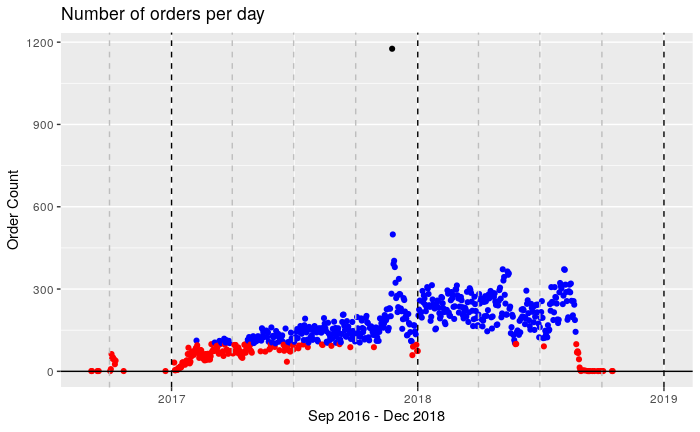

The plot reveals the following aspects of the data.  
a. The plot shows gaps in between dates when orders were placed.  
Further analysis shows the gaps between dates in the dataset as follows:

```sql
WITH d AS (
    SELECT DATE(order_purchase_timestamp) AS day,
           LAG(DATE(order_purchase_timestamp)) OVER
              (ORDER BY DATE(order_purchase_timestamp)) AS previous_date
    FROM orders
)
SELECT previous_date AS date, day AS next_date,
       datediff(day, previous_date) AS gap_between_dates
FROM d
WHERE DATEDIFF(day, previous_date) > 1
ORDER BY DATEDIFF(day, previous_date) DESC
```

[output not shown]

2. The trend shoots up during the 4th quarter of 2017 and the order placed per  
   day sees a steep rise.
3. One data point shows extreme deviation of 1176 orders on a single day on 24th  
   November 2017. This count deviated greatly from the Median of 148 orders and  
   Mean of 156 orders.

```sql
WITH d AS (
    SELECT DISTINCT DATE(order_purchase_timestamp) AS date,
           COUNT(order_id) OVER (PARTITION BY DATE(order_purchase_timestamp))
              AS count_orders
    FROM orders
)
SELECT date, count_orders
FROM d
ORDER BY count_orders DESC
```

| date | count_orders |
| --- | --- |
| 2017-11-24 | 1176 |
| 2017-11-25 | 499 |
| 2017-11-27 | 403 |
| 2017-11-26 | 391 |
| 2017-11-28 | 380 |
| 2018-05-07 | 372 |
| 2018-08-06 | 372 |
| 2018-08-07 | 370 |
| 2018-05-14 | 364 |
| 2018-05-16 | 357 |

[output cut: 624 more lines]

Hence we can conclude that the data reported through orders.csv is not conducive  
for creating a predictive model.

7.8. Reviewing the location wise distribution of data:

```
 customer_state     customer_id_count customer_unique_id_count
 Length:27          Min.   :   46.0   Min.   :   46.0
 Class :character   1st Qu.:  381.5   1st Qu.:  381.5
 Mode  :character   Median :  907.0   Median :  907.0
                    Mean   : 3683.0   Mean   : 3683.0
                    3rd Qu.: 2760.0   3rd Qu.: 2760.0
                    Max.   :41746.0   Max.   :41746.0
```

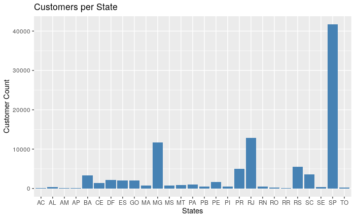

```sql
WITH d AS (
    SELECT DISTINCT customer_state,
           COUNT(customer_id) OVER (PARTITION BY customer_state)
              AS customer_id_count,
           COUNT(customer_unique_id) OVER (PARTITION BY customer_state)
              AS customer_unique_id_count
    FROM customers
)
SELECT customer_state, customer_id_count, customer_unique_id_count
FROM d
ORDER BY customer_id_count DESC
```

```sql
WITH d AS (
    SELECT DISTINCT c.customer_state,
           COUNT(o.order_id) OVER (PARTITION BY c.customer_state) AS orders_per_state
    FROM customers AS c
    JOIN orders AS o
    ON c.customer_id = o.customer_id
)
SELECT *
FROM d
ORDER BY orders_per_state DESC
```

| customer_state | orders_per_state |
| --- | --- |
| SP | 41746 |
| RJ | 12852 |
| MG | 11635 |
| RS | 5466 |
| PR | 5045 |
| SC | 3637 |
| BA | 3380 |
| DF | 2140 |
| ES | 2033 |
| GO | 2020 |

[output cut: 17 more lines]

7.9. Exploratory analysis reveals the following information regarding product deliveries.

1. There is a high deviation in estimated delivery dates and actual delivery to the customer.  
   The estimated delivery dates require further analysis for more realistic estimates.
2. There is a high deviation in delivery as per carrier and actual delivery to the customer.  
   Further investigation is required to drill into the issue.
3. There is a high deviation in delivery as per carrier and estimated delivery to the customer.  
   Further investigation is required to drill into the issue.

```sql
WITH d AS (
    SELECT c.customer_state,
           COUNT(o.order_id) OVER (PARTITION BY c.customer_state)
              AS total_orders,
           (DATEDIFF(DATE(o.order_estimated_delivery_date),
              DATE(o.order_purchase_timestamp))) AS purchase_estimated_delivery,
           (DATEDIFF(DATE(o.order_delivered_carrier_date),
              DATE(o.order_purchase_timestamp))) AS purchase_delivered_carrier,
           (DATEDIFF(DATE(o.order_delivered_customer_date),
              DATE(o.order_purchase_timestamp))) AS purchase_delivered_customer

    FROM customers AS c
    JOIN orders AS o
    ON c.customer_id = o.customer_id
)
SELECT DISTINCT d.customer_state, d.total_orders,
       ROUND(AVG(d.purchase_estimated_delivery) OVER (PARTITION BY d.customer_state), 2)
          AS avg_estimated_delivery,
       ROUND(AVG(d.purchase_delivered_carrier) OVER (PARTITION BY d.customer_state), 2)
          AS avg_delivered_carrier,
       ROUND(AVG(d.purchase_delivered_customer) OVER (PARTITION BY d.customer_state), 2)
          AS avg_delivered_customer

FROM d
ORDER BY d.total_orders DESC
```

4. The following states require attention as they deviate from the average delivery time.  
   Further investigation is required to drill into the issue.

```sql
WITH d AS (
    SELECT c.customer_state,
           COUNT(o.order_id) OVER (PARTITION BY c.customer_state)
              AS total_orders,
           (DATEDIFF(DATE(o.order_estimated_delivery_date),
              DATE(o.order_purchase_timestamp))) AS purchase_estimated_delivery,
           (DATEDIFF(DATE(o.order_delivered_carrier_date),
              DATE(o.order_purchase_timestamp))) AS purchase_delivered_carrier,
           (DATEDIFF(DATE(o.order_delivered_customer_date),
              DATE(o.order_purchase_timestamp))) AS purchase_delivered_customer

    FROM customers AS c
    JOIN orders AS o
    ON c.customer_id = o.customer_id
    ),
  d2 AS (
  SELECT DISTINCT d.customer_state, d.total_orders,
       ROUND(AVG(d.purchase_estimated_delivery) OVER (PARTITION BY d.customer_state), 2)
          AS avg_estimated_delivery,
       ROUND(AVG(d.purchase_delivered_carrier) OVER (PARTITION BY d.customer_state), 2)
          AS avg_delivered_carrier,
       ROUND(AVG(d.purchase_delivered_customer) OVER (PARTITION BY d.customer_state), 2)
          AS avg_delivered_customer
  FROM d
  ),
  d3 AS (
  SELECT customer_state, total_orders, avg_delivered_customer,
       AVG(d2.avg_delivered_customer) OVER () AS avg_delivery_Country
  FROM d2
  )
SELECT customer_state, total_orders, avg_delivered_customer AS avg_delivery_State,
       ROUND(avg_delivery_Country, 2) AS avg_delivery_Country
FROM d3
WHERE ((avg_delivery_Country) - (avg_delivered_customer)) < 0
ORDER BY total_orders DESC
```

[output not shown]

5. The following bubble chart shows total orders vs average delivery time. The size of the circle depicts order count. Colour gradient towards Blue indicates better delivery time. Colour gradient towards Red indicates worse delivery time. This chart will assist in identifying the states that requires attention to improve customer experience by improving delivery time.  
   For example, Sau Paulo has the largest volume of order and the best average delivery time.

```
 customer_state      total_orders     avg_estimated_delivery avg_delivered_carrier avg_delivered_customer
 Length:27          Min.   :   46.0   Min.   :19.81          Min.   :2.820         Min.   : 8.70
 Class :character   1st Qu.:  381.5   1st Qu.:26.80          1st Qu.:3.185         1st Qu.:15.39
 Mode  :character   Median :  907.0   Median :31.11          Median :3.300         Median :19.22
                    Mean   : 3683.0   Mean   :32.08          Mean   :3.343         Mean   :18.72
                    3rd Qu.: 2760.0   3rd Qu.:33.41          3rd Qu.:3.460         3rd Qu.:21.33
                    Max.   :41746.0   Max.   :47.17          Max.   :4.530         Max.   :29.34
```

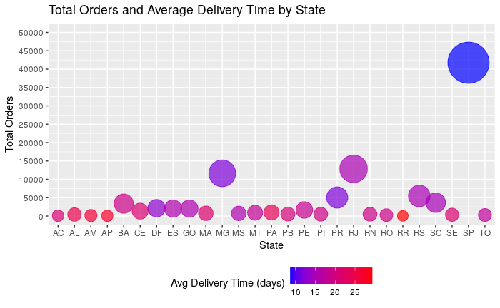

7.10. Analysis of products:

1. Top 2 selling products in each state is given by:

```sql
WITH d AS (
    SELECT DISTINCT c.customer_state, p.`product category`,
           COUNT(`product category`) OVER (PARTITION BY customer_state, `product category`)
              AS count_product
    FROM customers AS c
    JOIN orders AS o
    ON c.customer_id = o.customer_id
    JOIN order_items AS oi
    ON o.order_id = oi.order_id
    JOIN products AS p
    ON oi.product_id = p.product_id
    ),
  d2 AS (
    SELECT d.customer_state, d.`product category`, d.count_product,
       DENSE_RANK() OVER (PARTITION BY d.customer_state ORDER BY count_product DESC)
          AS product_rank
    FROM d
    )
SELECT d2.customer_state, d2.`product category`, d2.count_product, d2.product_rank
FROM d2
WHERE d2.product_rank <= 2 AND d2.count_product > 500
ORDER BY d2.customer_state, d2.product_rank, d2.count_product DESC
```

| customer_state | product category | count_product | product_rank |
| --- | --- | --- | --- |
| MG | bed table bath | 1331 | 1 |
| MG | HEALTH BEAUTY | 1086 | 2 |
| PR | Furniture Decoration | 520 | 1 |
| RJ | bed table bath | 1644 | 1 |
| RJ | Furniture Decoration | 1090 | 2 |
| RS | bed table bath | 614 | 1 |
| RS | Furniture Decoration | 561 | 2 |
| SP | bed table bath | 5235 | 1 |
| SP | HEALTH BEAUTY | 4204 | 2 |

2. Top selling products in the dataset are as follows:

```sql
SELECT DISTINCT p.`product category` AS product_category,
       COUNT(oi.order_item_id) OVER (PARTITION BY `product category`)
              AS count_product_category
FROM customers AS c
JOIN orders AS o
    ON c.customer_id = o.customer_id
JOIN order_items AS oi
    ON o.order_id = oi.order_id
JOIN products AS p
    ON oi.product_id = p.product_id
ORDER BY count_product_category DESC
```

| product_category | count_product_category |
| --- | --- |
| bed table bath | 11115 |
| HEALTH BEAUTY | 9670 |
| sport leisure | 8641 |
| Furniture Decoration | 8334 |
| computer accessories | 7827 |
| housewares | 6964 |
| Watches present | 5991 |
| telephony | 4545 |
| Garden tools | 4347 |
| automotive | 4235 |

[output cut: 63 more lines]

3. Sales trend in the data set for top selling product category:

```sql
WITH d AS (
    SELECT DISTINCT p.`product category` AS product_category,
           COUNT(oi.order_item_id) OVER (PARTITION BY `product category`)
              AS count_product_category
    FROM customers AS c
      JOIN orders AS o
        ON c.customer_id = o.customer_id
    JOIN order_items AS oi
        ON o.order_id = oi.order_id
    JOIN products AS p
        ON oi.product_id = p.product_id
  ),
  d2 AS (
    SELECT d.product_category, d.count_product_category,
           DENSE_RANK() OVER (ORDER BY d.count_product_category DESC)
                AS rank_category
    FROM d
  ),
  top_prod_cat AS (
    SELECT d2.product_category
    FROM d2
    WHERE d2.rank_category = 1
 )
SELECT DISTINCT DATE(o.order_purchase_timestamp) as day,
       COUNT(o.order_id) OVER (PARTITION BY DATE(o.order_purchase_timestamp))
            AS order_count
FROM customers AS c
  JOIN orders AS o
        ON c.customer_id = o.customer_id
  JOIN order_items AS oi
        ON o.order_id = oi.order_id
  JOIN products AS p
        ON oi.product_id = p.product_id
WHERE p.`product category` IN (SELECT product_category FROM top_prod_cat)
```

```
      day              order_count
 Min.   :2016-10-04   Min.   :  1.00
 1st Qu.:2017-06-06   1st Qu.: 10.00
 Median :2017-11-02   Median : 18.00
 Mean   :2017-11-01   Mean   : 18.59
 3rd Qu.:2018-03-31   3rd Qu.: 24.00
 Max.   :2018-08-28   Max.   :195.00
```

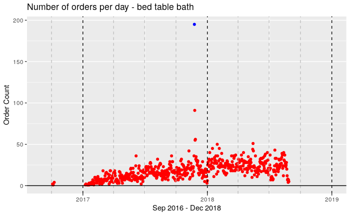

4. Sales trend in the data set for top 5 selling product category:

```
      day              order_count
 Min.   :2016-09-04   Min.   :  1.00
 1st Qu.:2017-05-28   1st Qu.: 43.00
 Median :2017-10-28   Median : 67.00
 Mean   :2017-10-26   Mean   : 74.61
 3rd Qu.:2018-03-29   3rd Qu.: 99.50
 Max.   :2018-08-29   Max.   :582.00
```

[figure not shown]

**Programming environment for analysis of the dataset is as follows**

1. RStudio for markdown and plotting.
2. MySQL as database server.
3. Docker for hosting RStudio and MySQL server.
4. Link to the [GitHub Repository for the case study](https://github.com/shayantandey/Scaler-DS-ML/tree/main/Business%20Case%20-%20SQL/Target%20Dataset).